# CSCI E-63C Week 9 assignment

# Preface

For this assignment we will use banknote authentication data (the one we worked with in week 2 assignment) to fit logistics regression model and evaluate performance of LDA, QDA and KNN classifiers. As we have seen earlier this dataset should allow to predict which banknotes are authentic and which ones are forged fairly well, so we should expect to see low error rates for our classifiers. Let’s see whether some of those tools perform better than others on this data.

```r
library(SDMTools)
```

```r
library(MASS)
library(ggplot2)
banknote <- read.table("data_banknote_authentication.txt", sep = ",")
colnames(banknote) <- c("variance","skewness","curtosis","entropy","class")
```

# Problem 1 (10 points): logistic regression

Fit logistic regression model of the class attribute using remaining four attributes as predictors in the model. Produce summary of the model, describe which attributes appear to be significantly associated with the categorical outcome in this model. Use this model to make predictions on the entire dataset and compare these predictions and corresponding true values of the class attribute using confusion matrix (i.e. contingency table). Calculate error rate (would this be training or test error in this case?), sensitivity and specificity (assuming that we are predicting class “1”). Describe the results.

```r
logistic <- glm(class~., data=banknote, family = binomial)
summary(logistic)
```

```
##
## Call:
## glm(formula = class ~ ., family = binomial, data = banknote)
##
## Deviance Residuals:
##      Min        1Q    Median        3Q       Max
## -1.70001   0.00000   0.00000   0.00029   2.24614
##
## Coefficients:
##             Estimate Std. Error z value Pr(>|z|)
## (Intercept)   7.3218     1.5589   4.697 2.64e-06 ***
## variance     -7.8593     1.7383  -4.521 6.15e-06 ***
## skewness     -4.1910     0.9041  -4.635 3.56e-06 ***
## curtosis     -5.2874     1.1612  -4.553 5.28e-06 ***
## entropy      -0.6053     0.3307  -1.830   0.0672 .
## ---
## Signif. codes:  0 '***' 0.001 '**' 0.01 '*' 0.05 '.' 0.1 ' ' 1
##
## (Dispersion parameter for binomial family taken to be 1)
##
##     Null deviance: 1885.122  on 1371  degrees of freedom
## Residual deviance:   49.891  on 1367  degrees of freedom
## AIC: 59.891
##
## Number of Fisher Scoring iterations: 12
```

```r
banknote$prediction <- predict(logistic, newdata=banknote, type="response")

confusion.matrix(banknote$class, banknote$prediction)
```

```
##     obs
## pred   0   1
##    0 757   6
##    1   5 604
## attr(,"class")
## [1] "confusion.matrix"
```

> variance, skewness, curtosis are significantly associated with the outcome.

> NPV = 757/763 = 0.9921363, PPV = 604/609 = 0.9917898, Sensitivity = 604/610 = 0.9901639, Specificity = 757/762 = 0.9934383

> The error rate is for training data.

# Problem 2 (10 points): LDA and QDA

Using LDA and QDA implementations available in the package `MASS`, calculate confusion matrix, (training) error rate, sensitivity and specificity for each of them. Compare them to those of logistic regression. Describe the results.

```r
lda.fit <- lda(class~., data=banknote)
banknote$prediction.lda <- predict(lda.fit, newdata=banknote)$posterior[,2]
confusion.matrix(banknote$class, banknote$prediction.lda)
```

```
##     obs
## pred   0   1
##    0 757   6
##    1   5 604
## attr(,"class")
## [1] "confusion.matrix"
```

> It is the same resuilt as logistic regression.

# Problem 3 (10 points): KNN

Using `knn` from library `class`, calculate confusion matrix, (training) error rate, sensitivity/specificity for one and ten nearest neighbors models. Compare them to corresponding results from LDA, QDA and logistic regression. Describe results of this comparison – discuss whether it is surprising to see low *training* error for KNN classifier with $k=1$.

```r
library(class)
knn.fit1 <- class::knn1(train=banknote[1:4],test=banknote[1:4],cl=as.factor(banknote$class))
confusion.matrix(banknote$class, as.numeric(knn.fit1))
```

```
##     obs
## pred   0   1
##    0   0   0
##    1 762 610
## attr(,"class")
## [1] "confusion.matrix"
```

```r
knn.fit10 <- class::knn(train=banknote[1:4],test=banknote[1:4],cl=as.factor(banknote$class),k=10, prob=TRUE)
confusion.matrix(banknote$class, as.numeric(knn.fit10))
```

```
##     obs
## pred   0   1
##    0   0   0
##    1 762 610
## attr(,"class")
## [1] "confusion.matrix"
```

# Problem 4 (30 points): compare test errors of logistic regression, LDA, QDA and KNN

Using resampling approach of your choice (e.g. cross-validation, bootstrap, etc.) obtain test error as well as sensitivity and specificity for each of these methods (logistic regression, LDA, QDA, KNN with $k=1,2,5,10,20,50,100$). Present results in the form of boxplots, compare test error/sensitivity/specificity across these methods and discuss their relative performance.

```r
nTries <- 30
resultDF <- data.frame()
for ( iTry in 1:nTries ) {
  banknote$rnd <- runif(nrow(banknote))
  train <- banknote[banknote$rnd<=0.8,]
  test <- banknote[banknote$rnd>0.8,]
  train$rnd <- NULL
  test$rnd <- NULL

  lr.fit <- glm(class~., data=train, family = binomial)
  test$prediction <- predict(lr.fit, newdata=test, type="response")
  performance <- accuracy(test$class, test$prediction)
  resultDF <- rbind(resultDF, data.frame("nTry"=iTry, "method"="lr.fit",
                                         "accuracy"=performance$prop.correct,
                                         "specificity"=performance$specificity,
                                         "sensitivity"=performance$sensitivity,
                                         "auc"=performance$AUC))

  lda.fit <- lda(class~., data=train)
  test$prediction <- predict(lda.fit, newdata=test)$posterior[,2]
  performance <- accuracy(test$class, test$prediction)
  resultDF <- rbind(resultDF, data.frame("nTry"=iTry, "method"="lda.fit",
                                         "accuracy"=performance$prop.correct,
                                         "specificity"=performance$specificity,
                                         "sensitivity"=performance$sensitivity,
                                         "auc"=performance$AUC))

  qda.fit <- qda(class~., data=train)
  test$prediction <- predict(qda.fit, newdata=test)$posterior[,2]
  performance <- accuracy(test$class, test$prediction)
  resultDF <- rbind(resultDF, data.frame("nTry"=iTry, "method"="qda.fit",
                                         "accuracy"=performance$prop.correct,
                                         "specificity"=performance$specificity,
                                         "sensitivity"=performance$sensitivity,
                                         "auc"=performance$AUC))

  knn.fit1<- class::knn1(train=train[1:4],test=test[1:4],cl=as.factor(train$class))
  performance <- accuracy(test$class, as.numeric(knn.fit1))
  resultDF <- rbind(resultDF, data.frame("nTry"=iTry, "method"="knn.fit1",
                                         "accuracy"=performance$prop.correct,
                                         "specificity"=performance$specificity,
                                         "sensitivity"=performance$sensitivity,
                                         "auc"=performance$AUC))

  knn.fit2<- class::knn(train=train[1:4],test=test[1:4],cl=as.factor(train$class),k=2, prob=TRUE)
  performance <- accuracy(test$class, as.numeric(knn.fit2))
  resultDF <- rbind(resultDF, data.frame("nTry"=iTry, "method"="knn.fit2",
                                         "accuracy"=performance$prop.correct,
                                         "specificity"=performance$specificity,
                                         "sensitivity"=performance$sensitivity,
                                         "auc"=performance$AUC))

  knn.fit5<- class::knn(train=train[1:4],test=test[1:4],cl=as.factor(train$class),k=5, prob=TRUE)
  performance <- accuracy(test$class, as.numeric(knn.fit5))
  resultDF <- rbind(resultDF, data.frame("nTry"=iTry, "method"="knn.fit5",
                                         "accuracy"=performance$prop.correct,
                                         "specificity"=performance$specificity,
                                         "sensitivity"=performance$sensitivity,
                                         "auc"=performance$AUC))

  knn.fit10<- class::knn(train=train[1:4],test=test[1:4],cl=as.factor(train$class),k=10, prob=TRUE)
  performance <- accuracy(test$class, as.numeric(knn.fit10))
  resultDF <- rbind(resultDF, data.frame("nTry"=iTry, "method"="knn.fit10",
                                         "accuracy"=performance$prop.correct,
                                         "specificity"=performance$specificity,
                                         "sensitivity"=performance$sensitivity,
                                         "auc"=performance$AUC))

  knn.fit20<- class::knn(train=train[1:4],test=test[1:4],cl=as.factor(train$class),k=20, prob=TRUE)
  performance <- accuracy(test$class, as.numeric(knn.fit20))
  resultDF <- rbind(resultDF, data.frame("nTry"=iTry, "method"="knn.fit20",
                                         "accuracy"=performance$prop.correct,
                                         "specificity"=performance$specificity,
                                         "sensitivity"=performance$sensitivity,
                                         "auc"=performance$AUC))

  knn.fit50<- class::knn(train=train[1:4],test=test[1:4],cl=as.factor(train$class),k=50, prob=TRUE)
  performance <- accuracy(test$class, as.numeric(knn.fit50))
  resultDF <- rbind(resultDF, data.frame("nTry"=iTry, "method"="knn.fit50",
                                         "accuracy"=performance$prop.correct,
                                         "specificity"=performance$specificity,
                                         "sensitivity"=performance$sensitivity,
                                         "auc"=performance$AUC))

  knn.fit100<- class::knn(train=train[1:4],test=test[1:4],cl=as.factor(train$class),k=100, prob=TRUE)
  performance <- accuracy(test$class, as.numeric(knn.fit100))
  resultDF <- rbind(resultDF, data.frame("nTry"=iTry, "method"="knn.fit100",
                                         "accuracy"=performance$prop.correct,
                                         "specificity"=performance$specificity,
                                         "sensitivity"=performance$sensitivity,
                                         "auc"=performance$AUC))

}
```

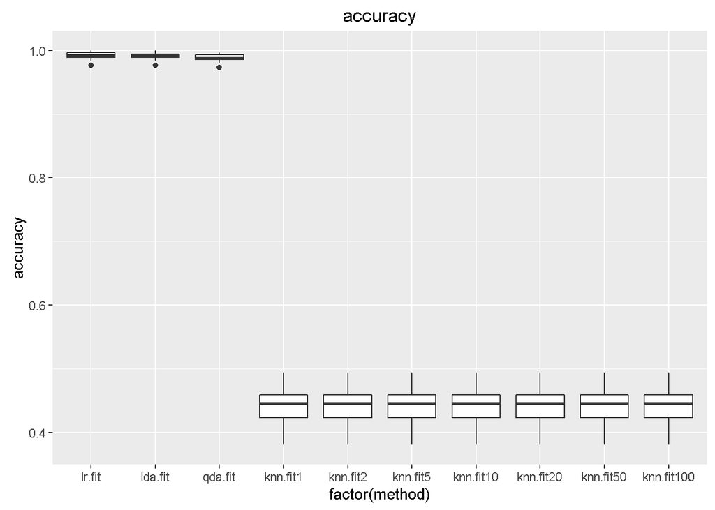

```r
ggplot(resultDF,aes(x=factor(method),y=accuracy)) + geom_boxplot() + ggtitle("accuracy")
```

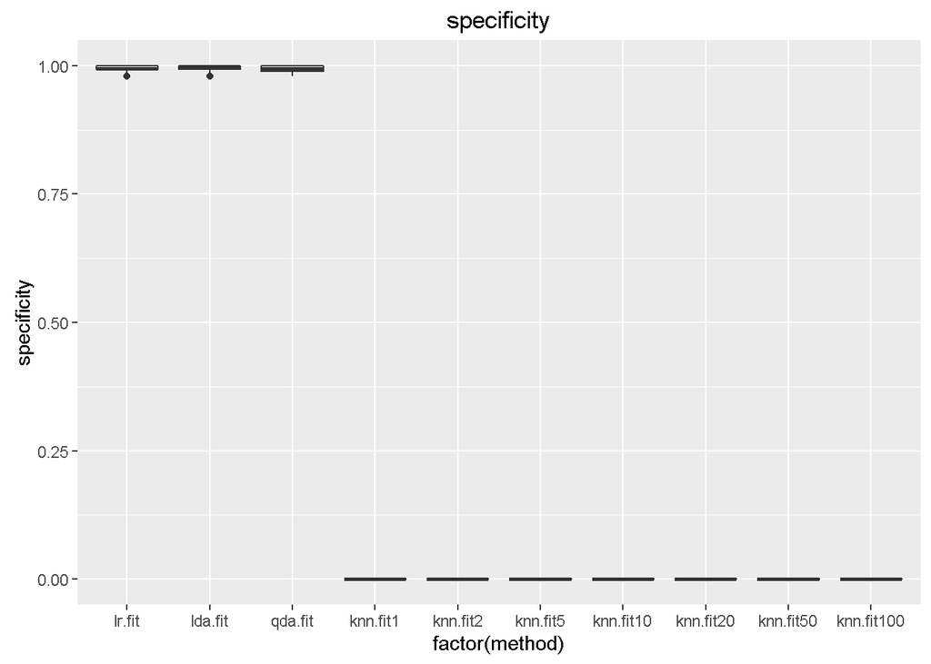

```r
ggplot(resultDF,aes(x=factor(method),y=specificity)) + geom_boxplot() + ggtitle("specificity")
```

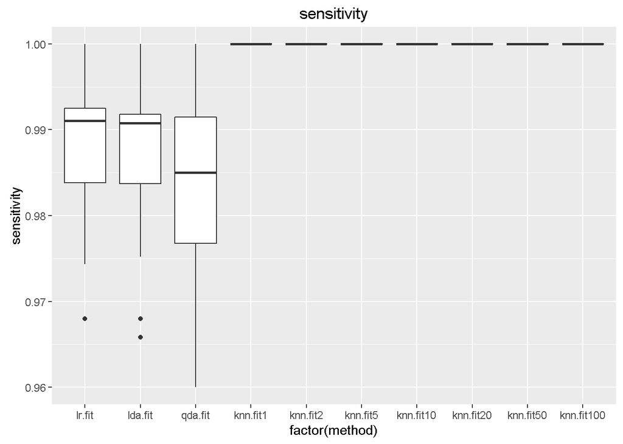

```r
ggplot(resultDF,aes(x=factor(method),y=sensitivity)) + geom_boxplot() + ggtitle("sensitivity")
```

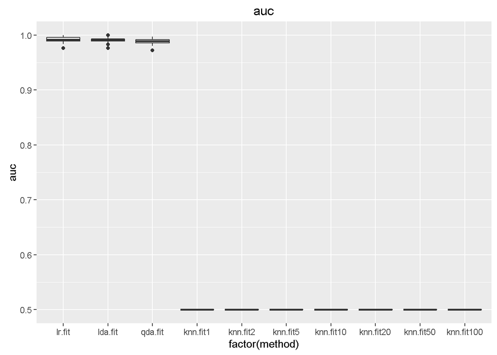

```r
ggplot(resultDF,aes(x=factor(method),y=auc)) + geom_boxplot() + ggtitle("auc")
```

# Extra 10 points problem: naive Bayes classifier

Fit naive Bayes classifier (see lecture slides for examples of using `naiveBayes` function from package `e1071`) on banknote authentication dataset and assess its performance on test data by resampling along with logistic regression, LDA, QDA and KNN in Problem 4 above. In other words, add naive Bayes to the rest of the methods evaluated above.